# SMDS Homework - Block 4

M. Castelli, M. Zambon, N. Miolato and J. A. Fernández Santisteban | Group ‘D’

27th May 2020

# Exercises from *DAAG* chapter 6

## Exercise 6

### Text:

The following invistigates the consequences of not using a logaritmic transformationfor the **nihills** data analysis. The second differs from the first in having a **dist $\times$ climb** interaction term, additional to linear terms in **dist** and **climb**.

1. Fit the two models:

```r
library(DAAG)
library(lattice)

nihills.lm <- lm(time ~ dist + climb, data = nihills)
nihills2.lm <- lm(time ~ dist + climb + dist:climb, data = nihills)
anova(nihills.lm, nihills2.lm)
```

```
## Analysis of Variance Table
##
## Model 1: time ~ dist + climb
## Model 2: time ~ dist + climb + dist:climb
##   Res.Df      RSS Df Sum of Sq      F    Pr(>F)
## 1     20 0.189361
## 2     19 0.039361  1      0.15 72.406 6.623e-08 ***
## ---
## Signif. codes:  0 '***' 0.001 '**' 0.01 '*' 0.05 '.' 0.1 ' ' 1
```

2. Using the *F-test* result, make a tentative choice of model, and proceed to examine diagnostic plots. Are there any problematic observations? What happens if these points are removed? Refit both of the models, and check the diagnostics again.

### Solution:

```r
summary(nihills.lm)
```

```
##
## Call:
## lm(formula = time ~ dist + climb, data = nihills)
##
## Residuals:
##      Min       1Q   Median       3Q      Max
## -0.19857 -0.04824  0.01701  0.05539  0.21083
##
## Coefficients:
##               Estimate Std. Error t value Pr(>|t|)
## (Intercept) -2.286e-01  4.025e-02  -5.679 1.47e-05 ***
## dist         1.008e-01  1.382e-02   7.293 4.72e-07 ***
## climb        2.298e-04  2.893e-05   7.941 1.31e-07 ***
## ---
## Signif. codes:  0 '***' 0.001 '**' 0.01 '*' 0.05 '.' 0.1 ' ' 1
##
## Residual standard error: 0.0973 on 20 degrees of freedom
## Multiple R-squared:  0.9852, Adjusted R-squared:  0.9838
## F-statistic: 667.6 on 2 and 20 DF,  p-value: < 2.2e-16
```

```r
summary(nihills2.lm)
```

```
##
## Call:
## lm(formula = time ~ dist + climb + dist:climb, data = nihills)
##
## Residuals:
##      Min       1Q   Median       3Q      Max
## -0.07854 -0.03182 -0.01334  0.02894  0.08711
##
## Coefficients:
##              Estimate Std. Error t value Pr(>|t|)
## (Intercept) 4.677e-02  3.744e-02   1.249   0.2267
## dist        6.962e-02  7.427e-03   9.374 1.48e-08 ***
## climb       9.988e-05  2.040e-05   4.896   0.0001 ***
## dist:climb  9.964e-06  1.171e-06   8.509 6.62e-08 ***
## ---
## Signif. codes:  0 '***' 0.001 '**' 0.01 '*' 0.05 '.' 0.1 ' ' 1
##
## Residual standard error: 0.04552 on 19 degrees of freedom
## Multiple R-squared:  0.9969, Adjusted R-squared:  0.9964
## F-statistic:  2058 on 3 and 19 DF,  p-value: < 2.2e-16
```

```r
F.test <- var.test(nihills.lm, nihills2.lm)
F.test$estimate
```

```
## ratio of variances
##           4.570305
```

The *F-test* tell us that the second model has a lowest variance, around $4.57$ times smaller than the first model, and then it is more useful.

These two vectors below represent the leverage of every observations in *nihills*.

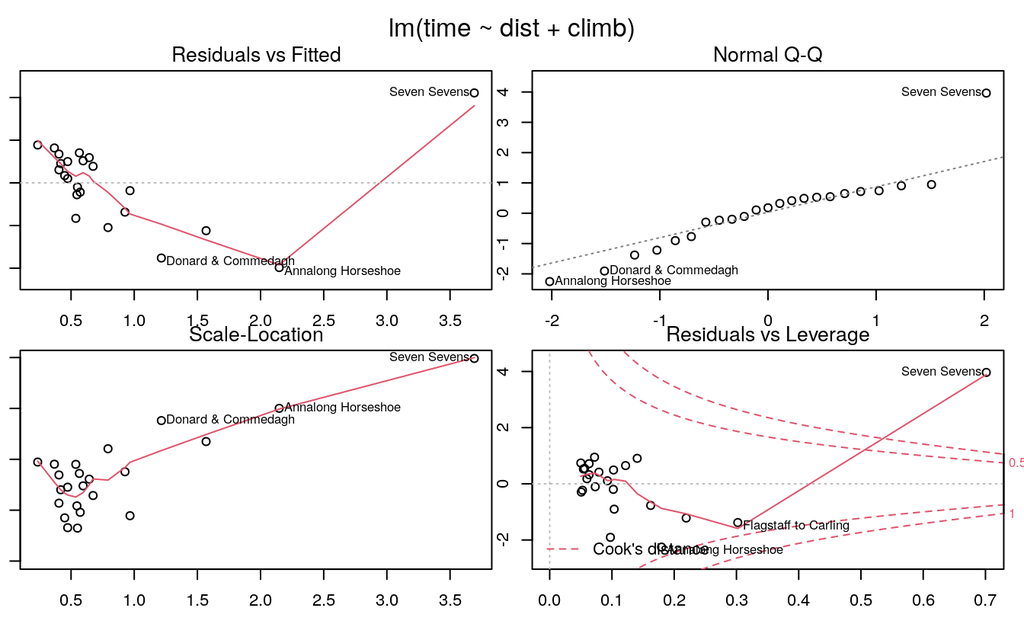

```r
par(mfrow = c(2, 2), oma = c(2, 0, 2, 0), mar = c(1.5, 1, 1.5, 1))
plot(nihills.lm)
```

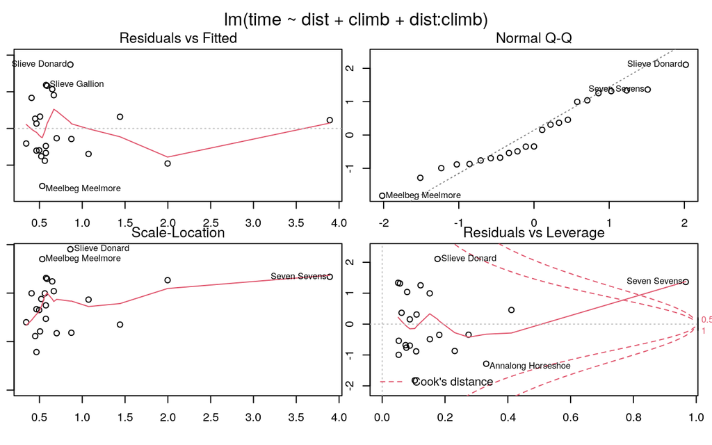

```r
plot(nihills2.lm)
```

```r
par(mfrow = c(1, 1))

as.vector(hatvalues(nihills.lm))
```

```
##  [1] 0.16220133 0.05980333 0.12191558 0.09751579 0.07315199 0.09276991
##  [7] 0.05269081 0.10257011 0.14055427 0.17963094 0.06331032 0.05615829
## [13] 0.05412630 0.10357534 0.05071683 0.10215939 0.30212390 0.21928184
## [19] 0.70134629 0.06331032 0.07202309 0.04998437 0.07907964
```

```r
as.vector(hatvalues(nihills2.lm))
```

```
##  [1] 0.18177757 0.07442190 0.12212315 0.23090878 0.07685139 0.10807128
##  [7] 0.05272216 0.10936534 0.15123359 0.33119064 0.08791144 0.05644305
## [13] 0.06171442 0.10372105 0.05245322 0.17625021 0.41145394 0.27498157
## [19] 0.96666666 0.08791144 0.15165030 0.05079949 0.07937744
```

We can see that there are some points that need to be checked. In particular observation $19$ has a leverage of almost $1$, and it’s the perfect candidate to be an outlier. There are also observations in positions $17$, $10$, $18$ and $4$ that should be checked.

```r
second_model <- nihills[-c(19), ]

nihills.lm <- lm(time ~ dist + climb, data = second_model)
nihills2.lm <- lm(time ~ dist + climb + dist:climb, data = second_model)
anova(nihills.lm, nihills2.lm)
```

```
## Analysis of Variance Table
##
## Model 1: time ~ dist + climb
## Model 2: time ~ dist + climb + dist:climb
##   Res.Df      RSS Df Sum of Sq      F Pr(>F)
## 1     19 0.040533
## 2     18 0.035509  1 0.0050248 2.5472 0.1279
```

```r
as.vector(hatvalues(nihills2.lm))
```

```
##  [1] 0.24672439 0.07803137 0.13835723 0.26948018 0.07817701 0.10837724
##  [7] 0.05392320 0.11656270 0.16665931 0.91354191 0.09846793 0.05912684
## [13] 0.06371829 0.10426829 0.05276137 0.22502454 0.41675004 0.32510251
## [19] 0.09846793 0.24018010 0.05183256 0.09446507
```

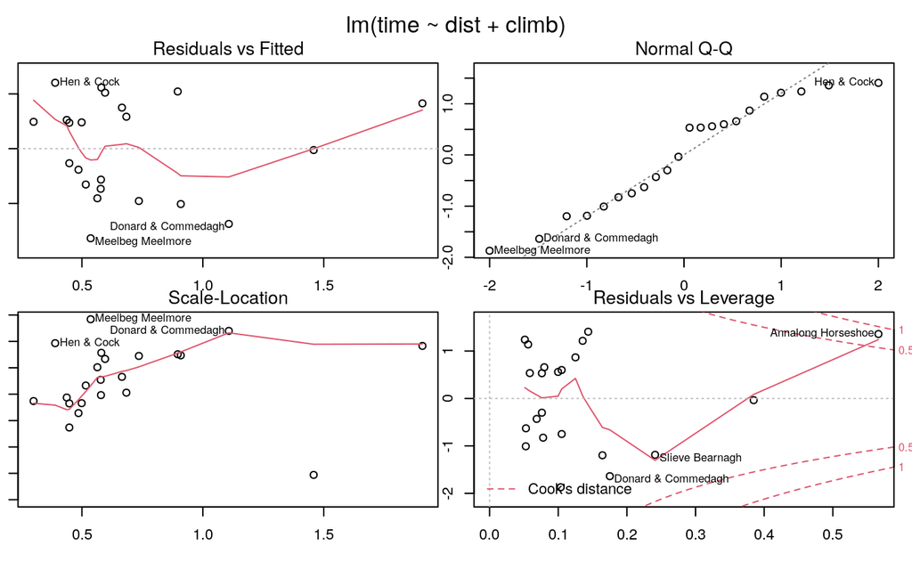

```r
par(mfrow = c(2, 2), oma = c(2, 0, 2, 0), mar = c(1.5, 1, 1.5, 1))
plot(nihills.lm)
```

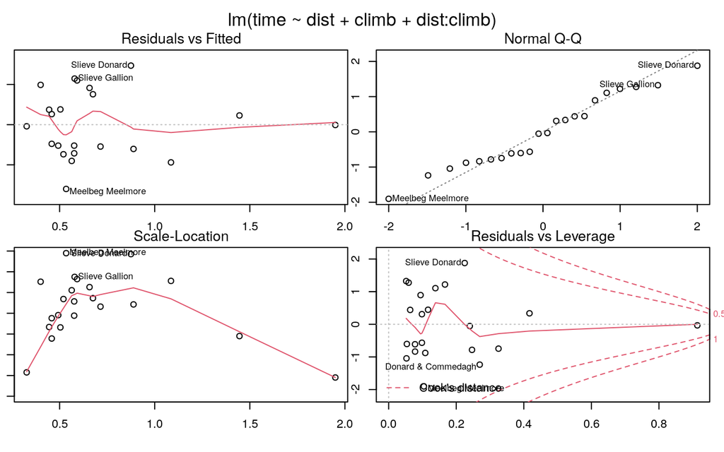

```r
plot(nihills2.lm)
```

```r
par(mfrow = c(1, 1))

F.test2 <- var.test(nihills.lm, nihills2.lm)
F.test2$estimate
```

```
## ratio of variances
##           1.081431
```

There are some problematic observations that should be removed to obtain a better model. There is an outlier that has a big leverage, and that is *“Seven Sevens”*, and and others that have a smaller leverage, but still affect the diagnostic plots. We chose to remove just *“Seven Sevens”* since it had a great influence and the models without those two were still good. We could have removed some other points, but all the models that came out were unbalanced and “create” new problematic observations. We think that the reason is that the model has only $23$ observations, and the outliers have a big role in these cases, and that’s why every time we remove a “problematic” observation the model change drastically.

## Exercise 8

### Text:

Apply the $\mathsf{lm.ridge()}$ function to $\mathsf{litters}$ data, using the generalized cross-validation (GCV) criterion to choose the tunning parameter. (GCV is an approximation to cross-validation).

1. In particular, estimate the coefficients of the model relating $\mathsf{brainwt}$ to $\mathsf{bodywt}$ and $\mathsf{lsize}$ and compare with the results obtained using $\mathsf{lm()}$.
2. Using both ridge and ordinary regression, estimate the mean brain weight when litter size is 10 and body weight is 7. Use the bootstrap, with case-resampling, to compute aproximate 95% percentile confidence intervals using each method. Compare with the interval obtained using $\mathsf{predict.lm()}$.

### Solution:

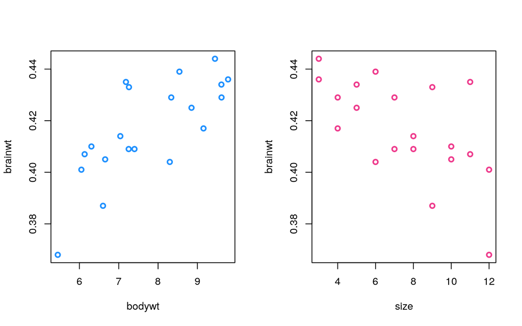

```r
library(DAAG)
library(MASS)

data <- litters

par(mfrow = c(1, 2))
plot(x=data$bodywt, y=data$brainwt, col="dodgerblue", lwd=2, ylab="brainwt", xlab="bodywt")
plot(x=data$lsize, y=data$brainwt, col="violetred2", lwd=2, ylab="brainwt", xlab="size")
```

```r
#brainwt vs bodywt + lsize
select(lm.ridge(brainwt ~ bodywt + lsize, data=data, lambda=seq(0,1,0.001)))
```

```
## modified HKB estimator is 0
## modified L-W estimator is 0
## smallest value of GCV  at 0.118
```

```r
litters.ridge = lm.ridge(brainwt ~ bodywt + lsize, data=data, lambda=0.118)
litters.lm = lm(brainwt ~ bodywt + lsize, data=data)

#lm coefs
litters.lm$coefficients
```

```
## (Intercept)      bodywt       lsize
## 0.178246962 0.024306344 0.006690331
```

The data displayed in the plots seems much disperse. It is not clear to be or not a linear relationship. However it can be trained a linear model as requested and then perform some diagnostic tests. In this case it has been trained a simple linear model with $\mathsf{lm()}$ function and a ridge one with $\mathsf{lm.ridge()}$ function. The coefficients of $\mathsf{lm}$ model are the previous ones while the ones or the ridge model are the following:

```r
coef(litters.ridge)
```

```
##                  bodywt       lsize
## 0.203442601 0.022050278 0.005661579
```

As expected, in general the ridge coefficients are slightly srunk towards 0 except the intercept one. As preliminar control of quality about the fit, let us check the lm fit summary:

```r
summary(litters.lm)
```

```
##
## Call:
## lm(formula = brainwt ~ bodywt + lsize, data = data)
##
## Residuals:
##        Min         1Q     Median         3Q        Max
## -0.0230005 -0.0098821  0.0004512  0.0092036  0.0180760
##
## Coefficients:
##             Estimate Std. Error t value Pr(>|t|)
## (Intercept) 0.178247   0.075323   2.366  0.03010 *
## bodywt      0.024306   0.006779   3.586  0.00228 **
## lsize       0.006690   0.003132   2.136  0.04751 *
## ---
## Signif. codes:  0 '***' 0.001 '**' 0.01 '*' 0.05 '.' 0.1 ' ' 1
##
## Residual standard error: 0.01195 on 17 degrees of freedom
## Multiple R-squared:  0.6505, Adjusted R-squared:  0.6094
## F-statistic: 15.82 on 2 and 17 DF,  p-value: 0.0001315
```

The summary shows a poor fit: the confidences of the coefficients in p-value terms are low and $R^2$ is far from being 1. This result is aligned with the observation about the dispersion of the data mentioned previously. The $\mathsf{lm.ridge()}$ models does not have a $\mathsf{summary()}$ equivalent function, thus accuracy will be manually-computed later.

One way to check the prediction’s accuracy of the models is the usage of coverage intervals. The idea is to obtain confidence intervals for each prediction (in this case via bootstrap). c.i. have been calculated by using the percentile method. Then it can be taken the proportion of data within the confidence interval of the predition and use it as measurement of accuracy.

First of all, let us check the predictions for both $\mathsf{lm}$ and $\mathsf{lm.ridge}$ predictions by taking $\mathsf{bodywt=10}$ and $\mathsf{lsize=7}$ as input.

```r
preds <- c(0,0)

#estimate with lm
new <- data.frame(bodywt = 10, lsize = 7)
preds[1] <- predict.lm(litters.lm, newdata = new)[[1]]

#estimate with ridge
brainwt_ridge <- function(bodywt, lsize){
  return(coef(litters.ridge)[1] + coef(litters.ridge)[2]*bodywt + coef(litters.ridge)[3]*lsize)
  }
preds[2] <- brainwt_ridge(10, 7)

#lm prediction and ridge prediction
preds
```

```
## [1] 0.4681427 0.4635764
```

Predictions are quite similar nevertheless it does not indicate anything about the prediction accuracy. In order to check it in a more general way, let us compute the coverage percentages using all the data as said before.

```r
#compute percentile c.i. for "stat" applied to "data" using "nreps" repetitions. "preds"
#is an array with the predictions
ci_bootstrap <- function(data, nreps, stat, preds){
  n <- nrow(data)
  ci <- as.data.frame(preds)
  ci$lwr <- rep(0, n)
  ci$upr <- rep(0, n)

  stat_samples <- matrix(data=NA, nrow=n, ncol=nreps)

  for (i in 1:nreps)
  {
    indexes <- sample(1:n, n, replace=TRUE)
    stat_samples[,i] <- stat(data[indexes,], data)
  }

  for (i in 1:n)
  {
    ci$lwr[i] <- quantile(stat_samples[i,], prob=0.025)
    ci$upr[i] <- quantile(stat_samples[i,], prob=0.975)
  }

  return(ci)
}

#train lm model with "data" and predict each instance of "data_new"
lm_predict <- function(data, data_new){
  lm_model <- lm(brainwt ~ bodywt + lsize, data=data)
  preds <- predict.lm(lm_model, data_new)
  names(preds) <- NULL
  return(preds)
}

#train ridge model with "data" and predict each instance of "data_new"
ridge_predict <- function(data, data_new){
  n_new <- nrow(data_new)
  ridge_model <- lm.ridge(brainwt ~ bodywt + lsize, data=data, lambda=0.118)
  coefs <- coef(ridge_model)
  preds <- rep(coefs[1], n_new) + data_new$bodywt*coefs[2] + data_new$lsize*coefs[3]
  names(preds) <- NULL
  return(preds)
}

#lm coverage percentage
preds_lm <- lm_predict(data, data)
coverage_lm <- ci_bootstrap(data, nreps=1000, lm_predict, preds_lm)
n_lm<-nrow(coverage_lm)
freq_coverage_lm <- sum(data$brainwt > coverage_lm[,2] & data$brainwt < coverage_lm[,3])/n_lm

#ridge coverage percentage
preds_ridge <- ridge_predict(data, data)
coverage_ridge <- ci_bootstrap(data, nreps=1000, ridge_predict, preds_ridge)
n_ridge<-nrow(coverage_ridge)
freq_coverage_ridge <- sum(data$brainwt > coverage_ridge[,2] & data$brainwt < coverage_ridge[,3])/n_ridge

#predict coverage percentage
coverage <- predict(litters.lm, interval="confidence")
n_pred<-nrow(coverage)
freq_coverage_lm_automatic <- sum(data$brainwt > coverage[,2] & data$brainwt < coverage[,3])/n_pred

#resulting coverage freqs
c(freq_coverage_lm_automatic, freq_coverage_lm, freq_coverage_ridge)
```

```
## [1] 0.55 0.45 0.40
```

## Exercise 10

### Text:

The data frame $\mathsf{table.b3}$ in the *MPV* package contains data on gas mileage and 11 other variables for a sample of 32 automobiles.

1. Construct a scatterplot of $\mathsf{y}$ (mpg) versus $\mathsf{x1}$ (displacement). Is the relationship between these variables non-linear?
2. Use the $\mathsf{xyplot()}$ function, and $\mathsf{x11}$ (type of transmission) as a $\mathsf{group}$ variable. Is a linear model reasonable for these data?
3. Fit the model relating $\mathsf{y}$ to $\mathsf{x1}$ and $\mathsf{x11}$ which gives two lines having possibly different slopes and intercepts. Check the diagnostics. Are there any influential informations? Are there any influential outlyers?
4. Plot the residuals against the variable $\mathsf{x7}$ (number of transmission speeds), again using $\mathsf{x11}$ as a $\mathsf{group}$ variable. Is there anything striking about this plot?

### Solution:

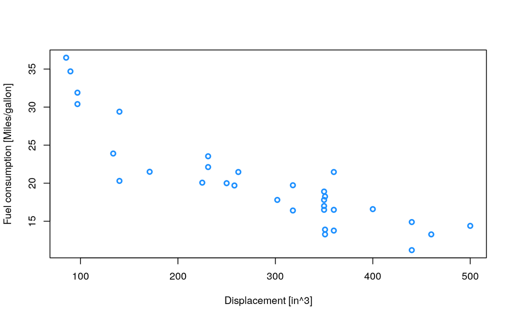

```r
library(DAAG)
library(MPV)
data <- table.b3

par(mfrow = c(1, 1))
plot(table.b3$x1, table.b3$y, xlab="Displacement [in^3]", ylab="Fuel consumption [Miles/gallon]",
     pch=1, col="dodgerblue", lwd=2)
```

The relationship between the displacement and the fuel consumption does not seem much linear, particullary at the beginning of the plot. Diferenciting among transmissin types, the plot results as the following one. Let us remind that the displacement is directly related with the power of an engine which is at the same time the energy increase by unit of time. Kinetic energy in this case comes directly from the chemical energy of the fuel, thus greater displacement implies, in general, greater fuel consumption as can be seen in the behavior of the plot.

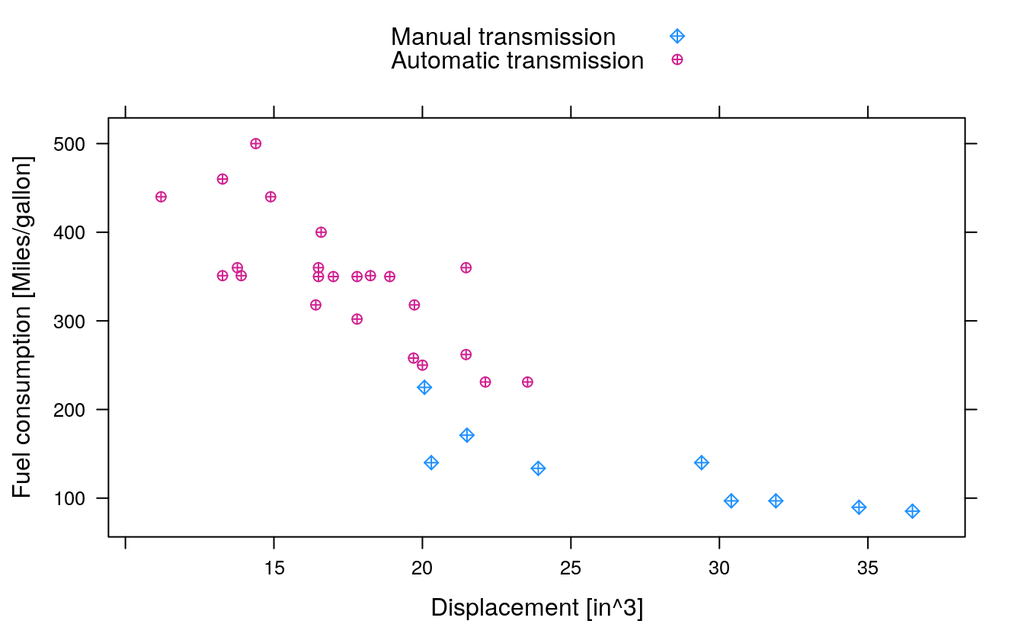

```r
par(mfrow = c(1, 1))
xyplot(x1 ~ y, groups=x11, data=data,
       auto.key=list(text=c("Manual transmission", "Automatic transmission")),
       par.settings = list(superpose.symbol = list(col = c("dodgerblue","violetred"), pch = c(9, 10))),
       xlab="Displacement [in^3]", ylab="Fuel consumption [Miles/gallon]")
```

Now the plot can be reasonably seen as the union of two lines depending on the type of transmission. This fact could make physical sense since an automatic gearbox tends to optimize the change of gears in such a way that the fuel consumption get lower. Change a gear in the wron moment implies a extra-waste of energy on heat and, greater is the energy implied by the engine, greater is the portion of energy wasted due to human fails. In this context it coul make sense trying to fit the data with a multiple linear model including in the model the transmission type.

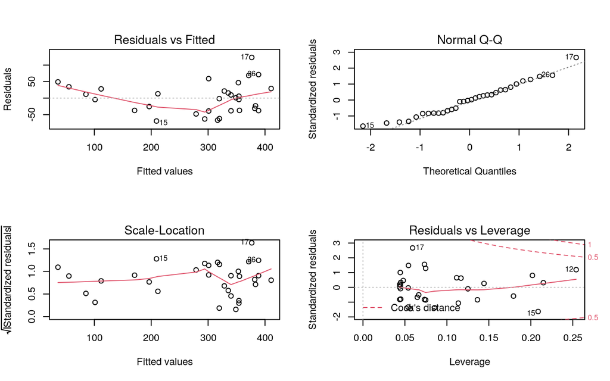

```r
model_lm <- lm(x1 ~ y + x11, data=data)
par(mfrow = c(2, 2))
plot(model_lm)
```

```r
summary(model_lm)
```

```
##
## Call:
## lm(formula = x1 ~ y + x11, data = data)
##
## Residuals:
##     Min      1Q  Median      3Q     Max
## -69.306 -37.336  -0.226  28.285 123.273
##
## Coefficients:
##             Estimate Std. Error t value Pr(>|t|)
## (Intercept)   426.35      58.28   7.316 4.66e-08 ***
## y             -10.69       2.03  -5.268 1.20e-05 ***
## x11           104.23      28.07   3.713 0.000867 ***
## ---
## Signif. codes:  0 '***' 0.001 '**' 0.01 '*' 0.05 '.' 0.1 ' ' 1
##
## Residual standard error: 47.62 on 29 degrees of freedom
## Multiple R-squared:  0.8456, Adjusted R-squared:  0.835
## F-statistic: 79.44 on 2 and 29 DF,  p-value: 1.712e-12
```

By looking to the diagnostics it seems to be some structure on the residuals distribution, particullary at the beginning, corresponding mainly to the cars with manual gearbox. However there is few data in that zone of the plot so, in general, residuals distribution can be considered more or less constant. The QQ plot shows an outlyer in the datum 17 but it is not much influential. In the summary, coefficients are significant and $R^2$ is not bad, but it could be better. This diagnostics indicates that the model, in general terms, is correct. However it is a certain lack of description in the dispersion of the data.

The mentioned lack of description in the dispersion invites to consider another additional variable. As seen previously, the type of gearbox has lot of impact on the fuel consumption, for this reason it could be also influent the number of gears. It can be plotted the residuals against the number of gears in order to try to detect if there is some kind of pattern. A boxplot has been used since the number of gears gathers lot of data, being practically categorical.

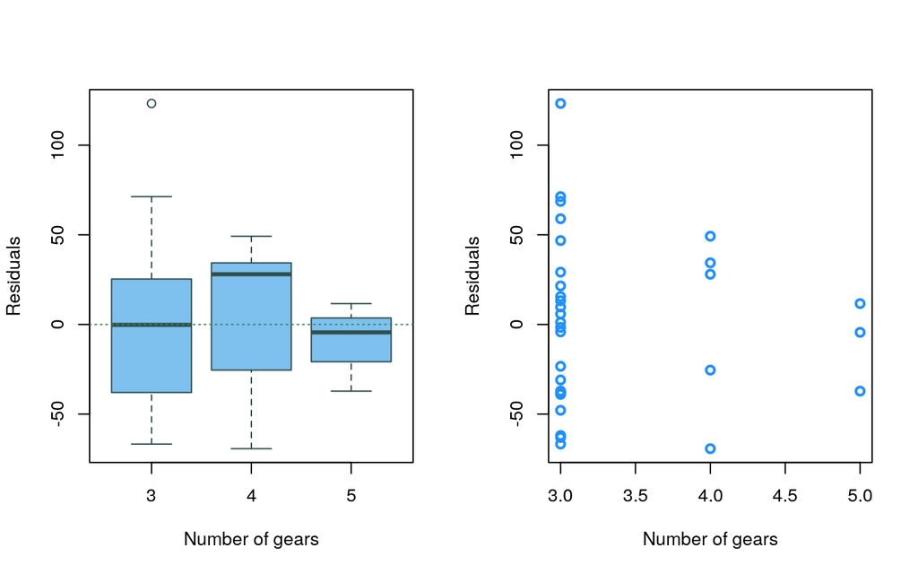

```r
res <- model_lm$residuals
names(res) <- NULL
res_gears <- data.frame(data$x7, res)
par(mfrow = c(1, 2))
boxplot(res ~ data.x7, res_gears, xlab="Number of gears", ylab="Residuals", col="skyblue2", border="darkslategrey")
abline(h=0, lty = 3, col="seagreen")
plot(res_gears, col="dodgerblue", xlab="Number of gears", ylab="Residuals", lwd=2, alpha=0.8)
```

In principle the most relevant feature is the decrease of the dispersion with the increase in the number of gears, indicating that this variable could be a good candidate to descrive the dispersion around the linear prediction. However, is important to note that the data is far from be homogeneous among the different classes (see the right plot), in particular, the amount of data decrease strongly with the number of gears. This heteroskedasticity problem makes weak the sense about hypotesis of the dependence between dispersion and number of gears.

## Exercise 11

### Text:

The following code is designed to explore effects that can result from the omission of explanatory variables. What happens if **x2** is generated according to **x2 <- rbinom(10, 1, x1)**? And **x2 <- rbinom(10, 1, 0.5)**?

### Solution:

```r
set.seed(1)

x1 <- runif(10)               # predictor which will be missing
x2 <- rbinom(10, 1, 1-x1)     # observed predictor which depends on missing predictor

y <- 5*x1 + x2 + rnorm(10, sd = 0.1) # simulated model; coef of x2 is positive

y.lm <- lm(y ~ factor(x2)) # model fitted to observed data
coef(y.lm)
```

```
## (Intercept) factor(x2)1
##    4.189118   -1.344441
```

```r
y.lm2 <- lm(y ~ x1 + factor(x2)) # correct model
coef(y.lm2)
```

```
## (Intercept)          x1 factor(x2)1
##   0.1331627   4.7993984   1.0039273
```

Repeating the same procedure using **x2 = rbinom(10, 1, x1)**.

```r
x2 <- rbinom(10, 1, x1)     # observed predictor which depends on missing predictor

y <- 5*x1 + x2 + rnorm(10, sd = 0.1) # simulated model; coef of x2 is positive

y.lm <- lm(y ~ factor(x2)) # model fitted to observed data
coef(y.lm)
```

```
## (Intercept) factor(x2)1
##    1.769703    2.620941
```

```r
y.lm2 <- lm(y ~ x1 + factor(x2)) # correct model
coef(y.lm2)
```

```
## (Intercept)          x1 factor(x2)1
##  -0.0764431   5.0391726   1.0658950
```

Repeating the same procedure using **x2 = rbinom(10, 1, 0.5)**.

```r
x2 <- rbinom(10, 1, 0.5)     # observed predictor which depends on missing predictor

y <- 5*x1 + x2 + rnorm(10, sd = 0.1) # simulated model; coef of x2 is positive

y.lm <- lm(y ~ factor(x2)) # model fitted to observed data
coef(y.lm)
```

```
## (Intercept) factor(x2)1
##    2.632427    1.277112
```

```r
y.lm2 <- lm(y ~ x1 + factor(x2)) # correct model
coef(y.lm2)
```

```
## (Intercept)          x1 factor(x2)1
##  0.01643269  5.01330928  0.97928145
```

In a similar way as the previous couple of models, the intercepts are much different: in the wrong model it’s around $2.6$, while in the correct model it’s around $0$, as it should be. This time **factor(x2)** is not too far from the correct value, since it is $1.27$ against the right value $0.98$.

Both couples of models are not very significant because the random samples from the various distributions have length $10$, and changing the **seed** in some cases make the wrong model to get values *not so far* from the correct model.

# Exercises from *DAAG* chapter 8

## Exercise 1

### Text

The following table shows numbers of occasions when inhibition (i.e., no flow of current across a membrane) occurred within 120 s, for different concentrations of the protein peptide-C (data are used with the permission of Claudia Haarmann, who obtained these data in the course of her PhD research). The outcome yes implies that inhibition has occurred.

| conc | 0.1 | 0.5 | 1 | 10 | 20 | 30 | 50 | 70 | 80 | 100 | 150 |
| --- | --- | --- | --- | --- | --- | --- | --- | --- | --- | --- | --- |
| no | 7 | 1 | 10 | 9 | 2 | 9 | 13 | 1 | 1 | 4 | 3 |
| yes | 0 | 0 | 3 | 4 | 0 | 6 | 7 | 0 | 0 | 1 | 7 |

Use logistic regression to model the probability of inhibition as a function of protein concentration.

### Solution

```r
#data
conc <- c(0.1,0.5,1,10,20,30,50,70,80,100,150)
no <- c(7,1,10,9,2,9,13,1,1,4,3)
yes <- c(0,0,3,4,0,6,7,0,0,1,7)

#total number of cases
n <- no+yes

#probability of inhibition
prob <- yes/n

#logistic regression model with conc
inihibit.glm <- glm(prob ~ (conc), family = binomial(link = "logit"), weights = n)

summary(inihibit.glm)
```

```
##
## Call:
## glm(formula = prob ~ (conc), family = binomial(link = "logit"),
##     weights = n)
##
## Deviance Residuals:
##     Min       1Q   Median       3Q      Max
## -1.8159  -1.0552  -0.6878   0.3667   1.0315
##
## Coefficients:
##             Estimate Std. Error z value Pr(>|z|)
## (Intercept) -1.32701    0.33837  -3.922 8.79e-05 ***
## conc         0.01215    0.00496   2.450   0.0143 *
## ---
## Signif. codes:  0 '***' 0.001 '**' 0.01 '*' 0.05 '.' 0.1 ' ' 1
##
## (Dispersion parameter for binomial family taken to be 1)
##
##     Null deviance: 16.683  on 10  degrees of freedom
## Residual deviance: 10.389  on  9  degrees of freedom
## AIC: 30.988
##
## Number of Fisher Scoring iterations: 4
```

From the summary we can conclude that our predictor *conc* is informative, that is a good explanatory variable for our outcome. Indeed we can see that including *conc* as predictor the decrease in the deviance is greater than 1, meaning that the predictor *conc* explains a bit of the variability of our outcome variable. Furthermore increasing *conc* by one unit changes the logit probability of inhibition by a positive difference of 0.01215.

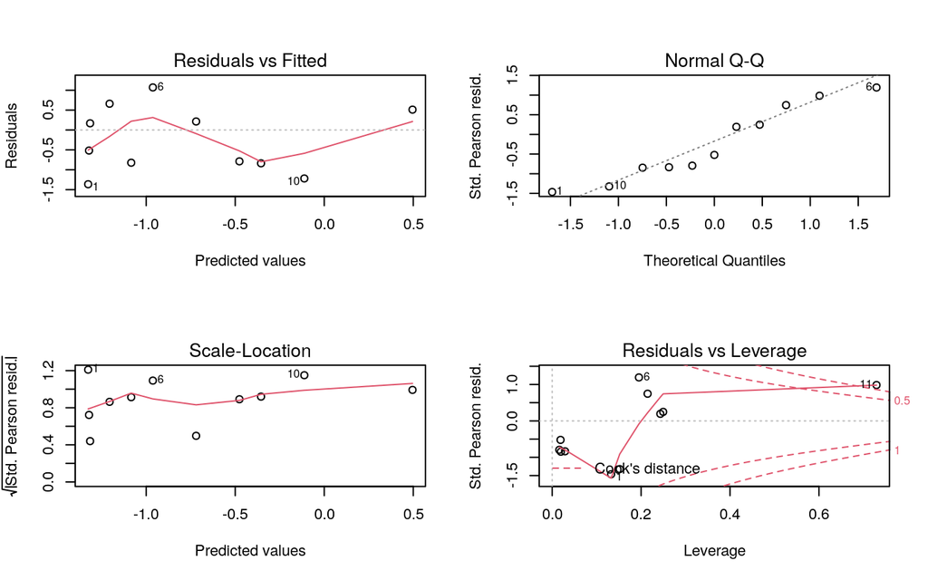

```r
par(mfrow=c(2,2))
plot(inihibit.glm)
```

Since from this plot we can identify a pattern, we try to apply some transformations to our predictor *conc*,such as the *log(conc)*, investigating if this can improve our model.

```r
#logistic regression using log(conc)
inihibit_log.glm <- glm(prob ~ I(log(conc)), family = binomial(link = "logit"), weights = n)

summary(inihibit_log.glm)
```

```
##
## Call:
## glm(formula = prob ~ I(log(conc)), family = binomial(link = "logit"),
##     weights = n)
##
## Deviance Residuals:
##     Min       1Q   Median       3Q      Max
## -1.2510  -1.0599  -0.5029   0.3152   1.3513
##
## Coefficients:
##              Estimate Std. Error z value Pr(>|z|)
## (Intercept)   -1.7659     0.5209  -3.390 0.000699 ***
## I(log(conc))   0.3437     0.1440   2.387 0.016975 *
## ---
## Signif. codes:  0 '***' 0.001 '**' 0.01 '*' 0.05 '.' 0.1 ' ' 1
##
## (Dispersion parameter for binomial family taken to be 1)
##
##     Null deviance: 16.6834  on 10  degrees of freedom
## Residual deviance:  9.3947  on  9  degrees of freedom
## AIC: 29.994
##
## Number of Fisher Scoring iterations: 4
```

```r
anova(inihibit.glm, inihibit_log.glm, test = "LRT")
```

```
## Analysis of Deviance Table
##
## Model 1: prob ~ (conc)
## Model 2: prob ~ I(log(conc))
##   Resid. Df Resid. Dev Df Deviance Pr(>Chi)
## 1         9    10.3887
## 2         9     9.3947  0    0.994
```

This results suggest that *log(conc)* is a reasonable explanatory variable for the occurence of inhibition in a period of 120s, and furthermore it is better to use this transformation of the variable instead of the original *conc*. Indeed comparing the two models we can see that using the *log(conc)* the AIC of the model is reduced, going from 30.988 to 29.994 and we have also a decrease of almost 1 in the residual deviance.